# Final Project: R Reference Guide

Ruichen Wang

2022-12-17

# R Reference Guide

Some shortcut run the code in a cell: Ctrl + Enter

Type “?” and then the function you need help in Console window provides explanation of the function.

## Loading Data and Packages

To load packages, we can use **library()** or **require()** functions. They do similar operations so either one is fine.

```r
# load the here and palmerpenguins packages using library()
library(here)
library(palmerpenguins)

# load the here and palmerpenguins packages using require()
require(here)
require(palmerpenguins)
```

```r
here()
```

```
## [1] "D:/UMass/Academic/Fall 2022/ECo 602/environmental_data"
```

```r
# create a data frame using here() and read.csv
ginkgo = read.csv(here("data", "ginkgo_data_2022.csv"))
ginkgo
```

```
##     site_id seeds_present max_width max_depth notch_depth petiole_length
## 1       216         FALSE        85        59        12.0             91
## 2       216         FALSE        72        54         0.0             56
## 3       216         FALSE        64        42         0.0             71
## 4       216         FALSE        76        48         0.0             44
## 5       216         FALSE        85        50         5.0             40
## 6       216         FALSE        75        46         7.0             50
## 7       216         FALSE        72        60         2.0             82
## 8       216         FALSE        81        60         0.0             84
## 9       216         FALSE        87        56         3.0             70
## 10      216         FALSE        87        54         9.0             40
## 11     1896         FALSE        94        60         4.0             70
## 12     1896         FALSE        92        83         3.0             88
## 13     1896         FALSE        70        42         3.0             43
## 14     1896         FALSE        84        54         6.0             59
```

[output cut: 206 more lines]

## Data Structures

The function **c()** combines or concatenates its arguments into a vector (a 1-dimensional data structure consisting of 1 or more elements).

All of the elements must be of the same type. I can’t combine character and numeric types in the same call to c() Here’s two examples using numeric and character data types:

```r
## Create a vector of numbers:
num_vec  = c(1, 4, 8, 9, 13)

## Create a vector of characters:
char_vec = c("a", "fish", "data is cool")
```

I can show the contents of a vector by typing the name of the vector, or using the print() function.

```r
## Typing the name of the vector into the console prints the contents
num_vec
```

```
## [1]  1  4  8  9 13
```

```r
## The print() function accomplishes the same task:
print(char_vec)
```

```
## [1] "a"            "fish"         "data is cool"
```

If I want to check the length of a vector, I can use **lengh()** function

```r
length(num_vec)
```

```
## [1] 5
```

```r
length(char_vec)
```

```
## [1] 3
```

**matrix()** function collects elements of the same data type (numeric, character, or logical) and arranges into a fixed number of rows and columns.

```r
#making a vector that contains integers from 1 to 12
Vec_4 = c(1:12)
#matrix cab be filled by rows
mat_1 = matrix(Vec_4, nrow = 3, byrow = TRUE)
mat_1
```

```
##      [,1] [,2] [,3] [,4]
## [1,]    1    2    3    4
## [2,]    5    6    7    8
## [3,]    9   10   11   12
```

```r
#by defalt, the matrix is filled by columns.
mat_2 = matrix(Vec_4, nrow = 3)
mat_2
```

```
##      [,1] [,2] [,3] [,4]
## [1,]    1    4    7   10
## [2,]    2    5    8   11
## [3,]    3    6    9   12
```

Data frames contain the variables of columns and rows that differ in data types.

```r
data.frame(ginkgo)
```

```
##     site_id seeds_present max_width max_depth notch_depth petiole_length
## 1       216         FALSE        85        59        12.0             91
## 2       216         FALSE        72        54         0.0             56
## 3       216         FALSE        64        42         0.0             71
## 4       216         FALSE        76        48         0.0             44
## 5       216         FALSE        85        50         5.0             40
## 6       216         FALSE        75        46         7.0             50
## 7       216         FALSE        72        60         2.0             82
## 8       216         FALSE        81        60         0.0             84
## 9       216         FALSE        87        56         3.0             70
## 10      216         FALSE        87        54         9.0             40
## 11     1896         FALSE        94        60         4.0             70
## 12     1896         FALSE        92        83         3.0             88
## 13     1896         FALSE        70        42         3.0             43
## 14     1896         FALSE        84        54         6.0             59
```

[output cut: 206 more lines]

**nrow()** and **ncol()** return the number of rows and columns of a data frame. **dim()** return the dimention of the data frame.

```r
nrow(ginkgo)
```

```
## [1] 220
```

```r
ncol(ginkgo)
```

```
## [1] 6
```

```r
dim(ginkgo)
```

```
## [1] 220   6
```

## Subsetting

One subset can be selected in a data frame by name using **$**.

```r
ginkgo$max_width
```

```
##   [1]  85  72  64  76  85  75  72  81  87  87  94  92  70  84  61 102  82  64
##  [19]  53  66  69  55  56  64  60  59  57  53  68  56  75  63  82  83  60  67
##  [37]  75  92 110  54  77  59  51 100  92  77  99  62  80  86  63  79  91  72
##  [55]  64  53  71  61  70  93  75  87  86  87  95  88  85  95  95  52  84  74
##  [73]  87  76  57  92  94  79  97  50 100  97  63  96  97  70  83  80  85 100
##  [91] 112 115  83 106  95  80 120  76  50  90  94  69  93  59  60 103  95  90
## [109]  80  90 106  98  73  89  65  83 116  90  86 104  92 103 100  91 102  99
## [127]  98 104  80  68  62  77  86  72  70  63  72  65  69  67  35  67  63  71
## [145]  77  60  70  69  55  72  84 106  61 114  95  86  60  78  86  91  79  95
## [163]  72 102  72 107  95  91  94  90  98  63  58  67  92  75  74  73  73  94
## [181]  76  86  78  74  89  77  80  71  69  81  39  60  50  47  52  61  56  45
## [199]  64  42 103  84 118 120 100 111 104  94  78  70  92  48  79  91 111  44
## [217] 117  93 101 145
```

I can use **[]** to select a subset by provide the position of the value I want.

```r
#select the first row in ginkgo data frame
ginkgo[1,]
```

```
##   site_id seeds_present max_width max_depth notch_depth petiole_length
## 1     216         FALSE        85        59          12             91
```

```r
#select the value at row 2, column 3
ginkgo[2,3]
```

```
## [1] 72
```

```r
#select the thrid column
ginkgo[3]
```

```
##     max_width
## 1          85
## 2          72
## 3          64
## 4          76
## 5          85
## 6          75
## 7          72
## 8          81
## 9          87
## 10         87
## 11         94
## 12         92
## 13         70
## 14         84
```

[output cut: 206 more lines]

I can use subset() to filter out all the data that belongs to this subset in a column. For example. retrieve all the data for Adelie penguins:

```r
subset(penguins, species == "Adelie")
```

```
## # A tibble: 152 × 8
##    species island    bill_length_mm bill_depth_mm flipper_…¹ body_…² sex    year
##    <fct>   <fct>              <dbl>         <dbl>      <int>   <int> <fct> <int>
##  1 Adelie  Torgersen           39.1          18.7        181    3750 male   2007
##  2 Adelie  Torgersen           39.5          17.4        186    3800 fema…  2007
##  3 Adelie  Torgersen           40.3          18          195    3250 fema…  2007
##  4 Adelie  Torgersen           NA            NA           NA      NA <NA>   2007
##  5 Adelie  Torgersen           36.7          19.3        193    3450 fema…  2007
##  6 Adelie  Torgersen           39.3          20.6        190    3650 male   2007
##  7 Adelie  Torgersen           38.9          17.8        181    3625 fema…  2007
##  8 Adelie  Torgersen           39.2          19.6        195    4675 male   2007
##  9 Adelie  Torgersen           34.1          18.1        193    3475 <NA>   2007
## 10 Adelie  Torgersen           42            20.2        190    4250 <NA>   2007
## # … with 142 more rows, and abbreviated variable names ¹flipper_length_mm,
## #   ²body_mass_g
```

## Numerical Data Exploration

Once I load a data frame, I can explore it and have an overview of my data. It is helpful to have a sense of data before doing any analysis. Below are functions that is very useful in numerical data exploration.

```r
#summary of ginkgo data frame
summary(ginkgo)
```

```
##     site_id      seeds_present     max_width        max_depth
##  Min.   :  216   Mode :logical   Min.   : 35.00   Min.   : 24.0
##  1st Qu.: 3470   FALSE:180       1st Qu.: 67.00   1st Qu.: 45.0
##  Median : 4874   TRUE :40        Median : 80.00   Median : 53.0
##  Mean   : 5726                   Mean   : 79.95   Mean   : 53.1
##  3rd Qu.: 6719                   3rd Qu.: 93.00   3rd Qu.: 60.0
##  Max.   :12982                   Max.   :145.00   Max.   :125.0
##   notch_depth     petiole_length
##  Min.   : 0.000   Min.   : 13.00
##  1st Qu.: 0.000   1st Qu.: 45.00
##  Median : 2.000   Median : 58.00
##  Mean   : 5.977   Mean   : 59.51
##  3rd Qu.: 6.250   3rd Qu.: 71.00
##  Max.   :92.000   Max.   :126.00
```

I can also see the summary, mean, and standard deviation of a specific column

```r
summary(ginkgo$max_width)
```

```
##    Min. 1st Qu.  Median    Mean 3rd Qu.    Max.
##   35.00   67.00   80.00   79.95   93.00  145.00
```

```r
mean(ginkgo$max_width)
```

```
## [1] 79.95455
```

```r
sd(ginkgo$max_width)
```

```
## [1] 18.16358
```

## Graphical Data Exploration

Explore the data graphically could be more direct than numerical exploration. Scatter plot, histogram, and boxplot are commonly used in graphical data exploration. Below is a scatter plot of max leaf depth and max leaf width from ginkgo data frame.

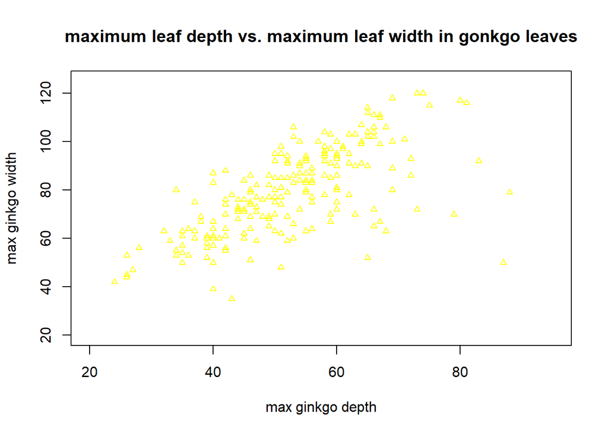

```r
plot(ginkgo$max_depth, ginkgo$max_width,
     col = "yellow",
     pch = 2,
     cex = 0.7,
     main = "maximum leaf depth vs. maximum leaf width in gonkgo leaves",
     xlab = "max ginkgo depth",
     ylab = "max ginkgo width",
     xlim = c(20, 95),
     ylim = c(20, 125))
```

A histogram of penguin flipper lengths:

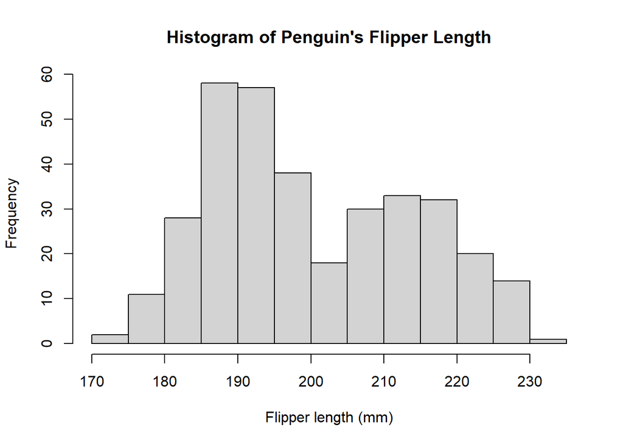

```r
hist(penguins$flipper_length_mm,
     main = "Histogram of Penguin's Flipper Length",
     xlab = "Flipper length (mm)",
     breaks = 15)
```

Simple boxplot of ginkgo petiole lengths

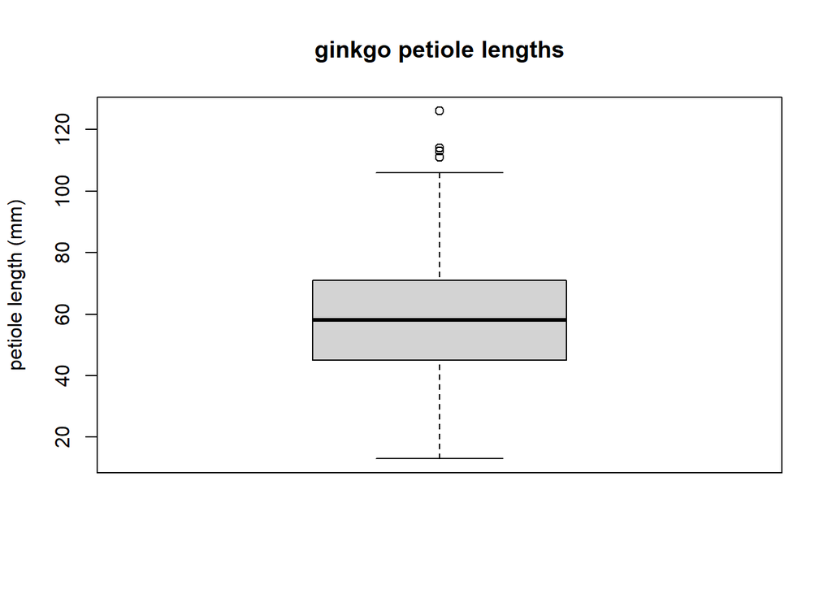

```r
boxplot(ginkgo$petiole_length,
        main = "ginkgo petiole lengths",
        ylab = "petiole length (mm)")
```

Conditional boxplot

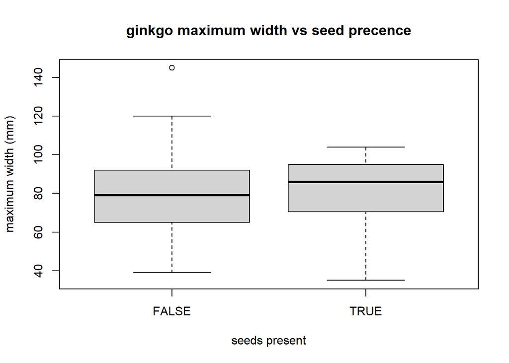

```r
boxplot(ginkgo$max_width ~ ginkgo$seeds_present,
        main = "ginkgo maximum width vs seed precence",
        xlab = "seeds present",
        ylab = "maximum width (mm)")
```

By using **par()** with the argument **mfrow**, I can create multiple plots arranged into a grid.

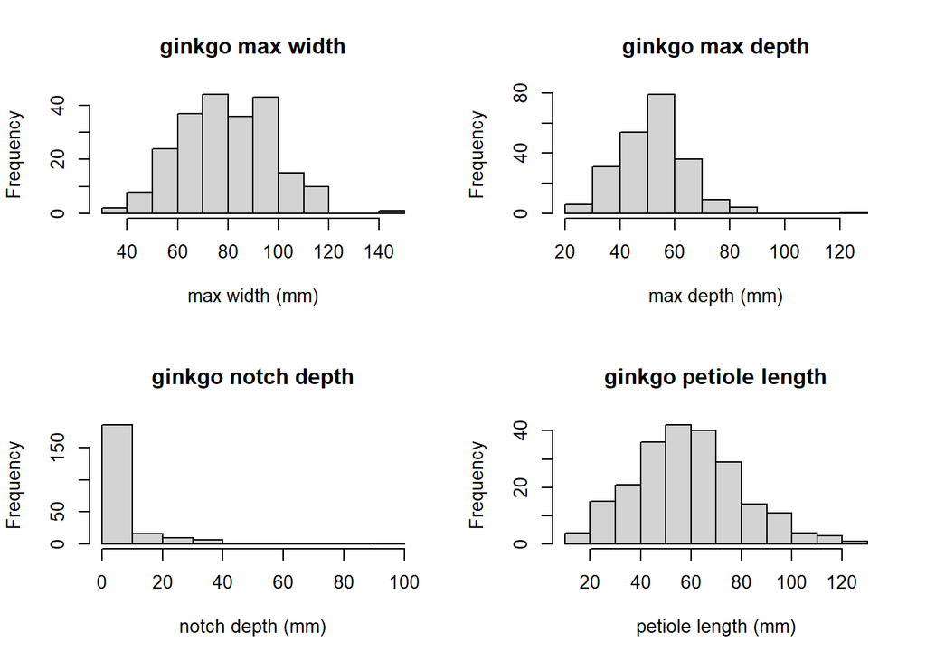

```r
par(mfrow = c(2,2))
hist(ginkgo$max_width, main = "ginkgo max width", xlab = "max width (mm)")
hist(ginkgo$max_depth, main = "ginkgo max depth", xlab = "max depth (mm)")
hist(ginkgo$notch_depth, main = "ginkgo notch depth", xlab = "notch depth (mm)")
hist(ginkgo$petiole_length, main = "ginkgo petiole length", xlab = "petiole length (mm)")
```

## Distribution Functions

The d functions calculate the probability density of a single event (what is probability of x = 3).

The p functions calculate the cumulative density of a single event (what is probability of x = 3 or less).

The q functions calculate the quantile function of a single event (what is the 90th percentile)

Normal distributions are used for continuous variables, the input parameters are mean and standard deviation of the sample.

Binomial distributions are used for discrete variables, the input parameters are number of trials in integer and probability of success on each trial.

```r
dnorm(3, mean = 10, sd = 3)
```

```
## [1] 0.00874063
```

```r
pnorm(3, mean = 10, sd = 3)
```

```
## [1] 0.009815329
```

```r
qnorm(0.9, mean = 10, sd = 3)
```

```
## [1] 13.84465
```

```r
dbinom(3, size = 10, prob = 0.3)
```

```
## [1] 0.2668279
```

```r
pbinom(3, size = 10, prob = 0.3)
```

```
## [1] 0.6496107
```

```r
qbinom(0.9, size = 10, prob = 0.3)
```

```
## [1] 5
```